# BAYESIAN INFERENCE FOR STANDARD DEVIATION

5 Apr 2021 (*updated: 2021-04-05)*

## i. Admin & Startup

## Week 11 Focus

- Receive and act on HW 7 Ch. 11-13, HW 8 Ch.14 feedback.
- Assess progress via Midterm 3 canvas quiz, due Friday Apr 9.
- Practice on HW 9 Ch.15, 16 content.
- Read Ch. 15, 16
- HW 9. Ch.15, 16 due Friday Apr 9.

## Today’s plan

- Prime by discussion via HW 9, Ch.15 exercise prompts.
- Discuss Ch. 15
- Summarize, Revisit HW or Q & A

*Please contribute questions and comments*

## I. Preview HW 9

- Ch.15: 4, C1.
- Ch.16: 2, C1, C3

## II. Discuss Ch. 15 with examples

- Overview
- 15.1 Bayes’ Thm for Normal Variance w/cont. prior
- 15.2 Some specific prior distributions and resultant posteriors
- Example 15.1
- 15.3 Bayesian Inference for Normal \(\sigma\).

## Overview

- Inference for standard deviation is usually secondary importance to location
- Two strategies we have seen: 1) assume it is known or 2) treat as a nuisance parameter and marginalize out
- In Ch.15 instead of focusing on the normal mean \(\mu\) we reverse the roles focus to \(\sigma\).

## 15.1 Bayes’ Thm for Normal Variance w/cont. prior

- Discuss Equation (15.1) Bayes rule.
- Discuss the *inverse chi-squared* and \(S\) times an *inverse chi-squared*, Equations (15.2-15.3)
- Inspect Figure 15.1.
- Show [wiki](https://en.wikipedia.org/wiki/Inverse-chi-squared_distribution) and discuss other notation.

## Likelihood of variance for a normal sample

- Derivation resulting in Eqn (15.4)
- Discuss footnote 2, form and df when \(\mu\) is unknown.

## 15.2 Some specific prior distributions and resultant posteriors

- work with \(\sigma^2\) for convenience.
- But set priors/interpret posterior on original scale \(\sigma\).
- Use the chain rule/change of variable formula to convert (15.5-15.6).

## Priors & Posteriors

- Positive uniform density for variance, posterior
- Positive uniform density for std dev, posterior
- Jeffrey’s prior density, posterior, footnote 4
- \(\mathrm{Scale-inv-}\chi^2\) prior
- Table 15.1
- Figures 15.3, 15.4
- Inverse gamma prior, discussion of default priors.

## Example 15.1

- Choice of priors, Fig.15.5.

```r
priorMedian <- 5
(fiftyPoint <- qchisq(p = 0.5, df = 1))
```

```
## [1] 0.4549364
```

```r
(priorS <- fiftyPoint*priorMedian^2)
```

```
## [1] 11.37341
```

## Example 15.1 con’d

```r
dat <- c(1011, 1009, 1019, 1012, 1011, 1016, 1018, 1021, 1016, 1012)
(n <- length(dat))
```

```
## [1] 10
```

```r
mu <- 1015
(sst <- sum( (dat - mu)^2 ))
```

```
## [1] 149
```

- Aroha’s flat prior induces a 149 \(\times \: \mathrm{inv-}\chi^2\) with 9 degrees of freedom posterior for \(\sigma^2\).
- Bernado’s Jeffrey’s prior induces a 149 \(\times \: \mathrm{inv-}\chi^2\) with 10 degrees of freedom posterior for \(\sigma^2\).
- Carlos’ prior of 11.3734106 \(\times \: \mathrm{inv-}\chi^2\) induces a 160.3734106 \(\times \: \mathrm{inv-}\chi^2\) with 11 degrees of freedom posterior for \(\sigma^2\).

## 15.3 Bayesian Inference for Normal \(\sigma\).

- Posterior mean, mode, median of variance and std dev on p.328
- Find central tendency for Example 15.1 in Table 15.2.
- Posterior Bayesian credible intervals for \(\sigma\):
- transform to chi-squared via \(W=S^{\prime}/sigma^2\) and use Equation (15.7).
- Find CIs for Example 15.1 in Table 15.3.
- Testing 1-sided hypothesis for Example 15.1 in Table 15.4.

## Using the `nvaricp` Bolstad function

```r
example(nvaricp)
```

```
##
## nvarcp> ## Suppose we have five observations from a normal(mu, sigma^2)
## nvarcp> ## distribution mu = 200 which are 206.4, 197.4, 212.7, 208.5.
## nvarcp> y = c(206.4, 197.4, 212.7, 208.5, 203.4)
##
## nvarcp> ## We wish to choose a prior that has a median of 8. This happens when
## nvarcp> ## S0 = 29.11 and kappa = 1
## nvarcp> nvaricp(y,200,29.11,1)
```

```
## S1: 321.9 kappa1 :6
##
## nvarcp> ##  Same as the previous example but a calculate a 95% credible
## nvarcp> ## interval for sigma. NOTE this method has changed
## nvarcp> results = nvaricp(y,200,29.11,1)
```

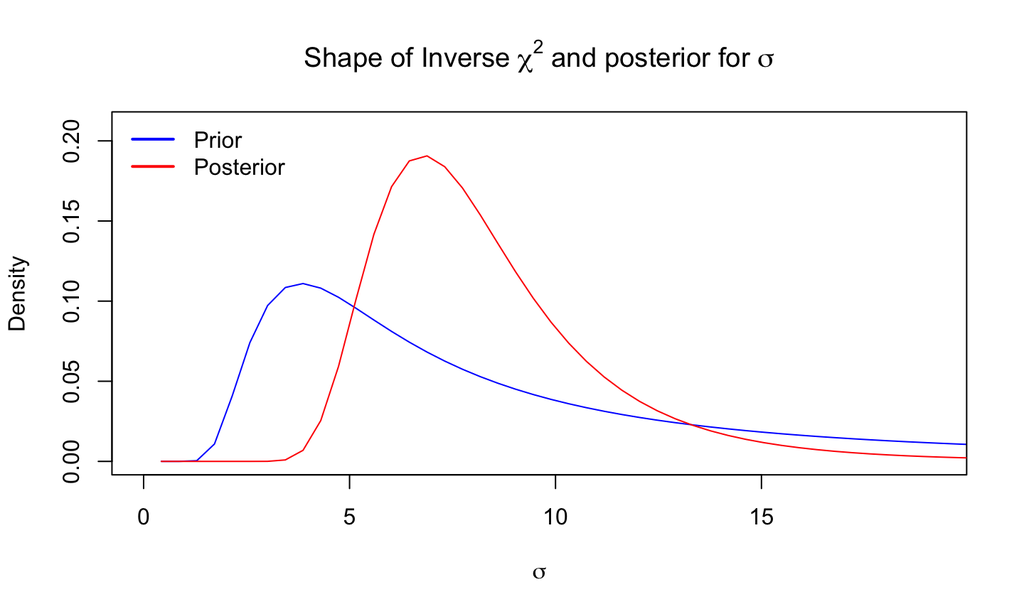

```
## S1: 321.9 kappa1 :6
##
## nvarcp> quantile(results, probs = c(0.025, 0.975))
## [1]  4.720154 16.130040
```

## Using the `nvaricp` Bolstad function

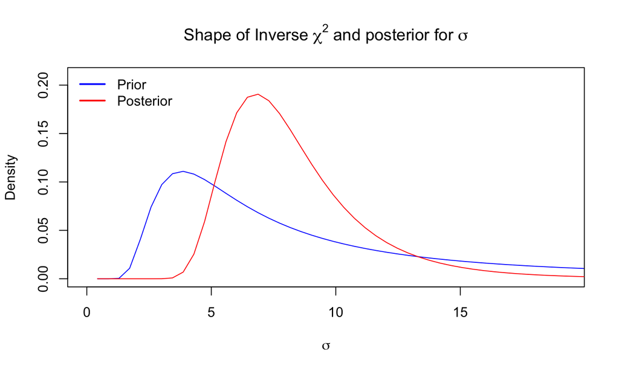

```r
example(nvaricp)
```

## Using the `nvaricp` Bolstad function

```r
res <- nvaricp(y = dat, mu = 1015, S0 = priorS, kappa = 1)
```

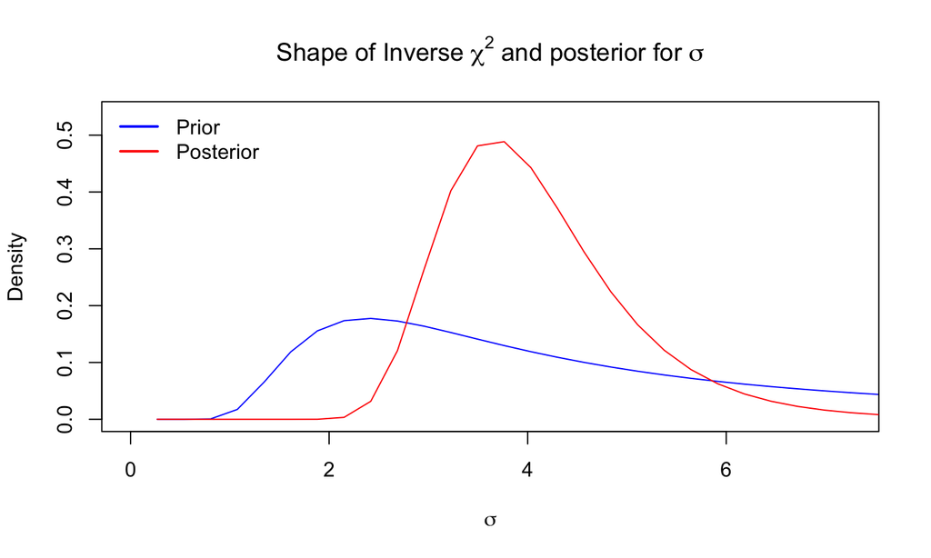

## Using the `nvaricp` Bolstad function

```r
res <- nvaricp(y = dat, mu = 1015, S0 = priorS, kappa = 1)
```

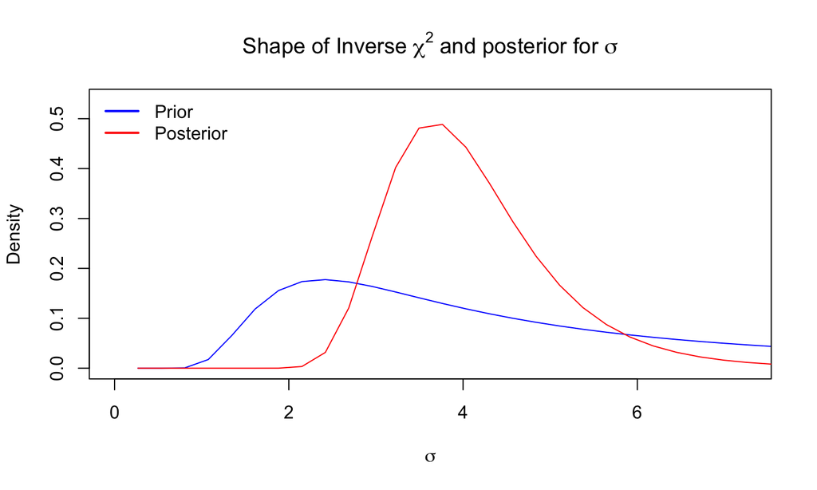

```r
mean(res)
## median(res) ## this errors for me.
quantile(res, probs = c(0.5))
quantile(res, probs = c(0.025, 0.975))
```

[output not shown]

## Closing (5 min)

Please contribute questions and comments while we review and discuss Ch.15 main points.